# Geospatial risk modeling - the case of crime (Robbery with Handgun)

Zizhao He

11/8/2019

## 1. Introduction and Basic Setup

For this assignment, I would conduct test the performance of my geospatal risk modeling to see if it could be recommended to city of Chicago to predict a specific type of crime, Robbery whose criminals used handguns.

Firstly, I loaded the requisite packages and created a theme to standardized all the map outputs that would be produced later. Then, I downloaded the data of Chicago Police Districts and Police Beats for later use. Afterwards, I used the newly downloaded boundary shapefile to create a 500ft grid cell lattice “fishnet” for later spatial analysis. Since only the grid cells in the boundary of Chicago is needed, I created a new fishnet with only those cells and plotted as the map below.

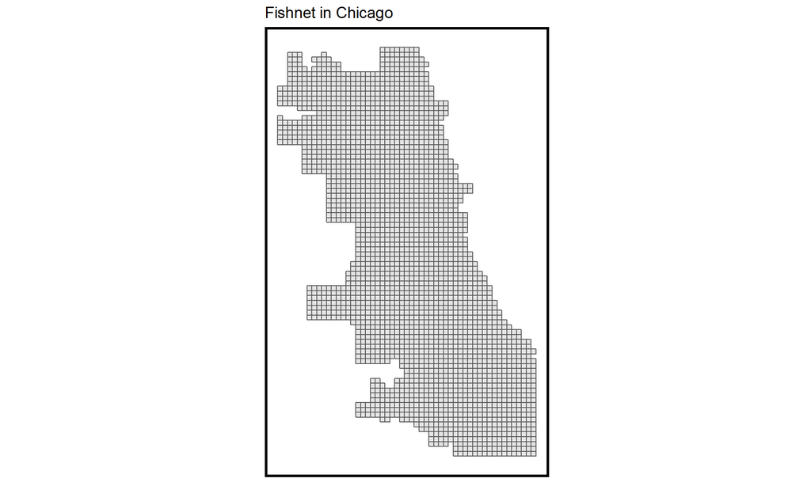

```r
fishnet <-
  fishnet[chicagoBoundary,] %>%
  mutate(uniqueID = rownames(.)) %>%
  dplyr::select(uniqueID)

ggplot() +
  geom_sf(data=fishnet) +
  labs(title = "Fishnet in Chicago") +
  mapTheme()
```

## 2. Data Wrangling

The next step is Data Wrangling. At first, I downloaded the crime data whose primary type is “ROBBERY” and Decription is “ARMED: HANDGUN” in 2017 as my outcome of interest.According to the location description, this type of crime only happens in Residence area. Thus, in summary, the object I’m interested in analyzing on is the robbery events happened in residential areas of Chicago in 2017 and the criminals were armed with handguns when committed a crime.

In my opinion, this type of crime would suffer a lot from selection bias. In fact, robbery is a kind of serious crimes, and the use of handguns made the criminals’ behavior worse and the consequences would be unforgivable, which indicates that the punishment the criminals would face would be severe. Thus, because of the high opportunity costs, the criminal must make sure the high return (money) of their behaviors, which means that they would be inclined to select the neighborhoods with relatively rich people or have few protections from the police and avoid the very poor or very safe (to residents) neighborhoods to implement their criminal plan. Thus, I believe selection bias may be an issue in my model.

### Deliverable 1. Map of Robberites with Handgun in point form.

Below is the map of my outcome of interest (robbery with handgun) in point form plotted on the boundary of Chicago:

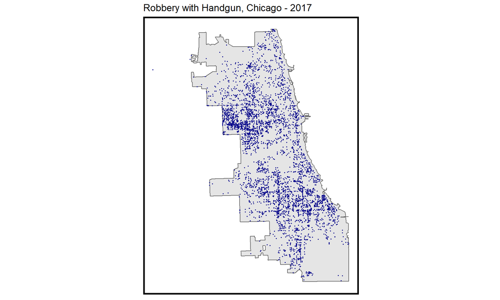

```r
# robbery with handgun throughout Chicago
ggplot() +
  geom_sf(data = chicagoBoundary) +
  geom_sf(data = rob, colour="dark blue", size=0.3, show.legend = "point") +
  labs(title= "Robbery with Handgun, Chicago - 2017") +
  mapTheme()
```

### Deliverable 2. Map of robberies in fishnet.

Then, I joined the robbery data to the fishnet and generated 24 subsets to allow 24-folds cross-validation later. Afterwards, I counted the robberies for each grid cell and plotted these crimes in fishnet as hotspots.

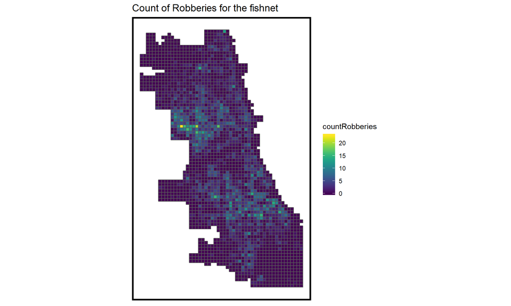

```r
ggplot() +
  geom_sf(data = crime_net, aes(fill = countRobberies)) +
  scale_fill_viridis() +
  labs(title = "Count of Robberies for the fishnet") +
  mapTheme()
```

According to the map, the distribution of the robberies seems having a pattern of clustering in Chicago.

### Deliverable 3. Small multiple map of risk factors in the fishnet.

And then, I wrangled the features of risk factors for the model. In fact, to help test the hypothesis that crime presence is a function of exposure to certain environmental characteristics, I downloaded eight risk factors from the 311 calls including records of rodent baiting, tree debris, abandoned cars, street lights out, graffiti remediation, sanitation complaints and abandon buildings; as well as the location of retail stores that sell liquor to go. In addition, I also downloaded the layer of neighborhoods in Chiago.

The next step is to engineer features to test the exposure hypothesis. To do that, at first, I calculated the number of robberies in each grid cell, spatially joined the fishnet to each crime point, and then converted the layer to a data frame. Furthermore, I transformed the long form layer of risk factor points within grid cells to a wide form layer of grid cells with risk factor columns. After counting the number of points, I mapped each count feature as part of a small multiple map.

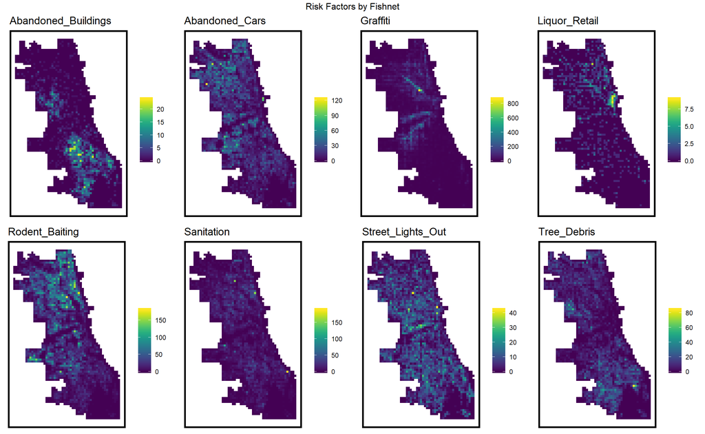

```r
# Map: Each count feature (for loop)
vars_net.long <-
  vars_net %>%
  gather(Variable, value, -geometry, -uniqueID)

vars <- unique(vars_net.long$Variable)
mapList <- list()

for(i in vars){
  mapList[[i]] <-
    ggplot() +
    geom_sf(data = filter(vars_net.long, Variable == i), aes(fill=value), colour=NA) +
    scale_fill_viridis(name="") +
    labs(title=i) +
    mapTheme()}

do.call(grid.arrange,c(mapList, ncol =4, top = "Risk Factors by Fishnet"))
```

According to the plots, the risk factors illustrated the spatial processes in slightly different patterns. Be specific, Abondon Buildings and Tree Debris are mainly clustering in South Chicago, while Abondon Cars and Rodent Baitings are mostly in the north, and Street Lights Out are most common in central area of the city. What’s more, the complaints of Graffiti tend to cluster along major thoroughfares. Liquor Retails and Sanitations are heavily clustered in the downtown area of Chicago.

In addition to the approach of counting features by grid cells, I also tested the hypothesis by calculating the average distances to 3 nearest neighbors, which is good for understanding local exposure to risk features. So, firstly, I created a function and calculated the distances.

```r
# NND--K=3
vars_net$Abandoned_Buildings.nn =
  nn_function(st_coordinates(st_centroid(vars_net)), st_coordinates(abandonBuildings), 3)

vars_net$Abandoned_Cars.nn =
  nn_function(st_coordinates(st_centroid(vars_net)), st_coordinates(abandonCars), 3)

vars_net$Graffiti.nn =
  nn_function(st_coordinates(st_centroid(vars_net)), st_coordinates(graffiti), 3)

vars_net$Liquor_Retail.nn =
  nn_function(st_coordinates(st_centroid(vars_net)), st_coordinates(liquorRetail), 3)

vars_net$Rodent_Baiting.nn =
  nn_function(st_coordinates(st_centroid(vars_net)), st_coordinates(Bait), 3)

vars_net$Street_Lights_Out.nn =
  nn_function(st_coordinates(st_centroid(vars_net)), st_coordinates(streetLightsOut), 3)

vars_net$Sanitation.nn =
  nn_function(st_coordinates(st_centroid(vars_net)), st_coordinates(sanitation), 3)

vars_net$Tree_Debris.nn =
  nn_function(st_coordinates(st_centroid(vars_net)), st_coordinates(treeDebris), 3)
```

And then, I plotted a small multiple map of the nearest neighbor features of the 8 risk factors by fishnet as below.

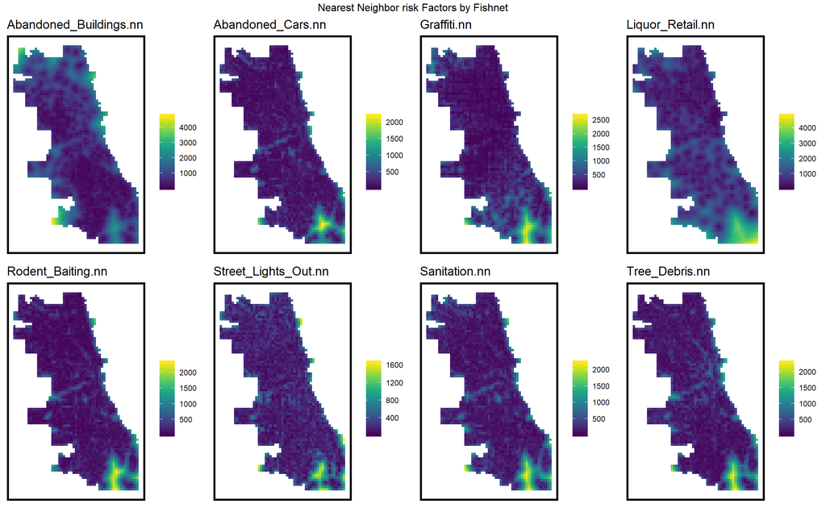

```r
# Plot of NND
vars_net.long.nn <-
  vars_net %>%
  dplyr::select(ends_with(".nn")) %>%
  gather(Variable, value, -geometry, -uniqueID)

vars <- unique(vars_net.long.nn$Variable)
mapList <- list()

for(i in vars){
  mapList[[i]] <-
    ggplot() +
    geom_sf(data = filter(vars_net.long.nn, Variable == i), aes(fill=value), colour=NA) +
    scale_fill_viridis(name="") +
    labs(title=i) +
    mapTheme()}

do.call(grid.arrange,c(mapList, ncol =4, top = "Nearest Neighbor risk Factors by Fishnet"))
```

As the maps shown, the nearest neighbor features of all newly generated risk factors seem to cluster in South Chicago, which is what we hope to see.

In the last step of feature engineering, I joined the “crime_net” and “vars_net” layers together into a final dataset, “final_net” and then spatially joined the neighborhood and Police District layers to the dataset by using grid cell centroids.

## 3. Exploring the spatial structure of robberies.

In the third section, I explored the spatial structure of robberies firstly through quantifing and visualizing by Local Moran’s I (a measure of spatial autocorrelation) and then through testing the correlation between these and other features and the count of robberies.

### Deliverable 4. Local Moran’s I related small multiple map.

The null hypothesis for Local Moran’s I is that robbery count at a given location is randomly distributed relative to its immeiate neighbors. Because a spatial weights matrix should be used to relate a unit to its neighbors, I created a neighbors list and the matrix. In the fishnet, each grid cell is related to its 8 closest neighbors.

Afterwards, I tried to describe the sptial process of interest. To do this, I firstly calculated the Local Moran’s I. And then, I tested the results of it and outputted several useful test statistics including the P values, and the hotspot cells whose p values are equal or less than 0.05. At last, I created a small multiple map including the maps of the count of robberies, Local Moran’s I, P values, and the significant hotspots.

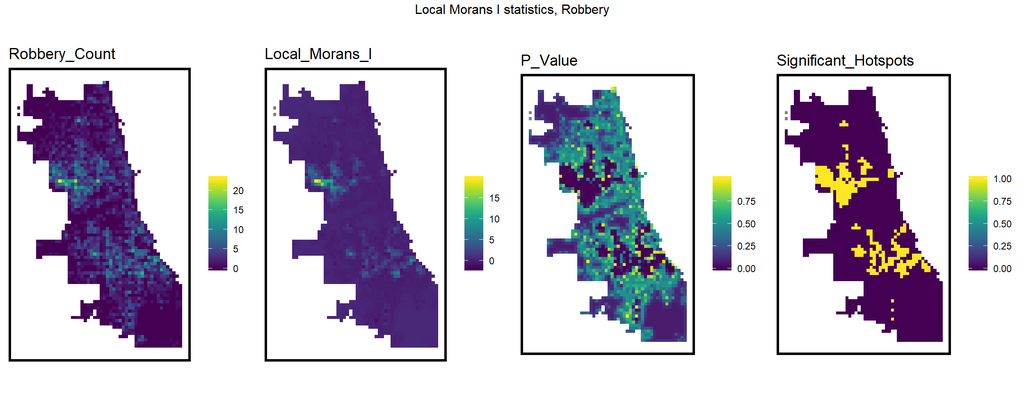

```r
final_net.localMorans <-
  cbind(
    as.data.frame(localmoran(final_net$countRobberies, final_net.weights)),
    as.data.frame(final_net, NULL)) %>%
  st_sf() %>%
  dplyr::select(Robbery_Count = countRobberies,
                Local_Morans_I = Ii,
                P_Value = `Pr(z > 0)`) %>%
  mutate(Significant_Hotspots = ifelse(P_Value <= 0.05, 1, 0)) %>%
  gather(Variable, Value, -geometry)

vars <- unique(final_net.localMorans$Variable)
varList <- list()

for(i in vars){
  varList[[i]] <-
    ggplot() +
    geom_sf(data = filter(final_net.localMorans, Variable == i), aes(fill = Value), colour=NA) +
    scale_fill_viridis(name="") +
    labs(title=i) +
    mapTheme()}

do.call(grid.arrange,c(varList, ncol = 4, top = "Local Morans I statistics, Robbery"))
```

In the maps above, the higher the value (color in yellow), the stronger and more statistically significant the evidence of local clustering the robbery is in Chicago. As the maps showed, the spatial autocorrelation in the midwest of Chicago is strong and the robbery spatial process has a clearly clustering pattern.

```r
# Distance to highly significant local robbery hotspots
final_net <-
  final_net %>%
  mutate(robbery.isSig = ifelse(localmoran(final_net$countRobberies,
                                            final_net.weights)[,5] <= 0.0000001, 1, 0)) %>%
  mutate(robbery.isSig.dist = nn_function(st_coordinates(st_centroid(final_net)),
                                           st_coordinates(st_centroid(
                                             filter(final_net, robbery.isSig == 1))), 1 ))
```

### Deliverable 5. Correlation Tests scatterplots.

In order to understand which type of feature for a given risk factor should be included in the model, I conducted a correlation test between counts of the robberies and each of the risk factors, and create a small multiple scatterplot that the counts as a function of the risk factors.

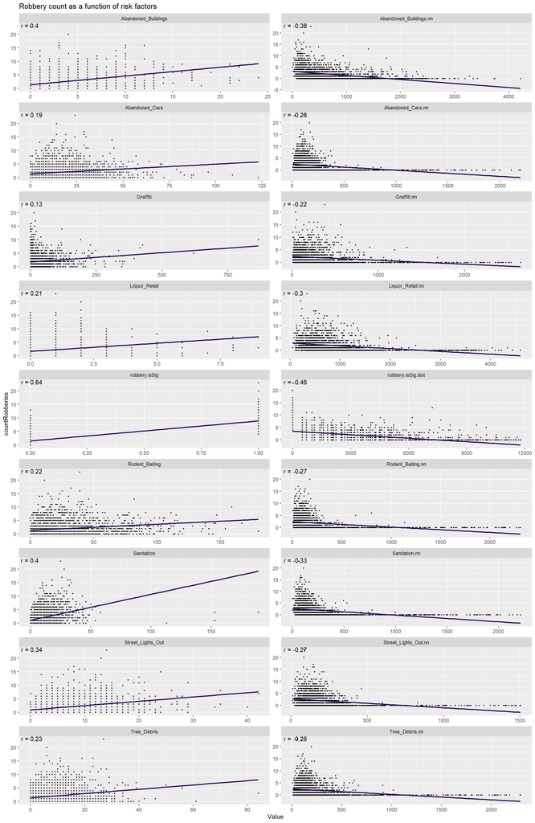

```r
correlation.long <-
  st_set_geometry(final_net, NULL) %>%
  dplyr::select(-uniqueID, -cvID, -name, -dist_num) %>%
  gather(Variable, Value, -countRobberies)

correlation.cor <-
  correlation.long %>%
  group_by(Variable) %>%
  summarize(correlation = cor(Value, countRobberies, use = "complete.obs"))

ggplot(correlation.long, aes(Value, countRobberies)) +
  geom_point(size = 0.5) +
  geom_text(data = correlation.cor, aes(label = paste("r =", round(correlation, 2))),
            x=-Inf, y=Inf, vjust = 1, hjust = -.1) +
  geom_smooth(method = "lm", se = FALSE, colour = "#320759") +
  facet_wrap(~Variable, ncol = 2, scales = "free") +
  labs(title = "Robbery count as a function of risk factors")
```

The plots above clearly showed that the count and nearest neighbor distance features of the risk factors are similar but with different direction of association. Actually, the slopes of the functions for the count of robberies and count of each risk factor are all positive and those of the functions for count of robberies and nearest neighbor distance of each factor are all negative.

Furthermore, if there’s a colinearity between count of robberies and either of the count or nearest neighbor distance features for a given risk factor, it should not be included in the model. In fact, from the plots we can be sure that all these factors could be included in the model.

## 4. Poisson Regression

### Deliverable 6. Histogram of dependent variable (Count of Robberies)

Before building the model for prediction, I firstly wanted to look at the distribution of the count of robberies which would be the dependent variable in the model. So, I plotted the distribution in a histogram.

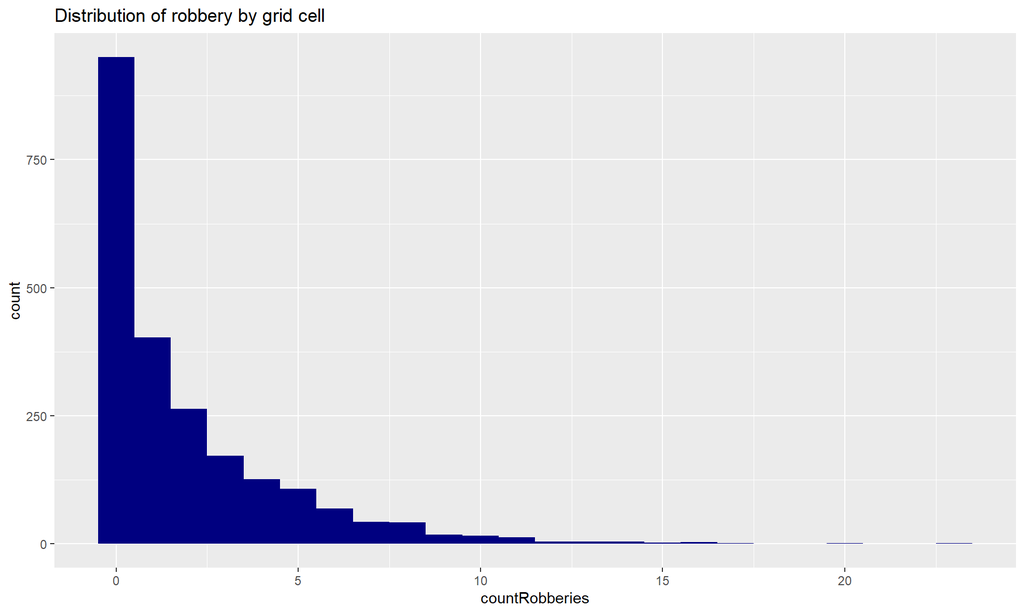

```r
# Distribution of count
ggplot(final_net, aes(countRobberies)) +
  geom_histogram(binwidth = 1, fill="navy") +
  labs(title = "Distribution of robbery by grid cell")
```

Since crime is relatively rare in real life, the distribution of the robberies by grid cell doesn’t normally distribute, but becomes far more skewed.Thus, an OLS regression is not good to be used on my data and Poisson Regression which is suited to modeling count outcome would be more appropriate.

### 4.1 Cross Validation.

Then, I performed spatial cross-validation to guage generalizability. In fact, I conducted both random k-fold and Leave-one-group-out (LOGO) cross validation for my model. What’s more, gooness of fit metrics are generated for both cross validation approaches for two different specifications (with or without spatial structure features).

### 4.2 Accuracy and generalizability.

Because generalizability in the models is more important than accuracy, I evaluated the accuracy in the context of generalizability with calculated errors.

Before evaluating the models with errors, I firstly mapped predictions for each regression (totally 4 of them) below.

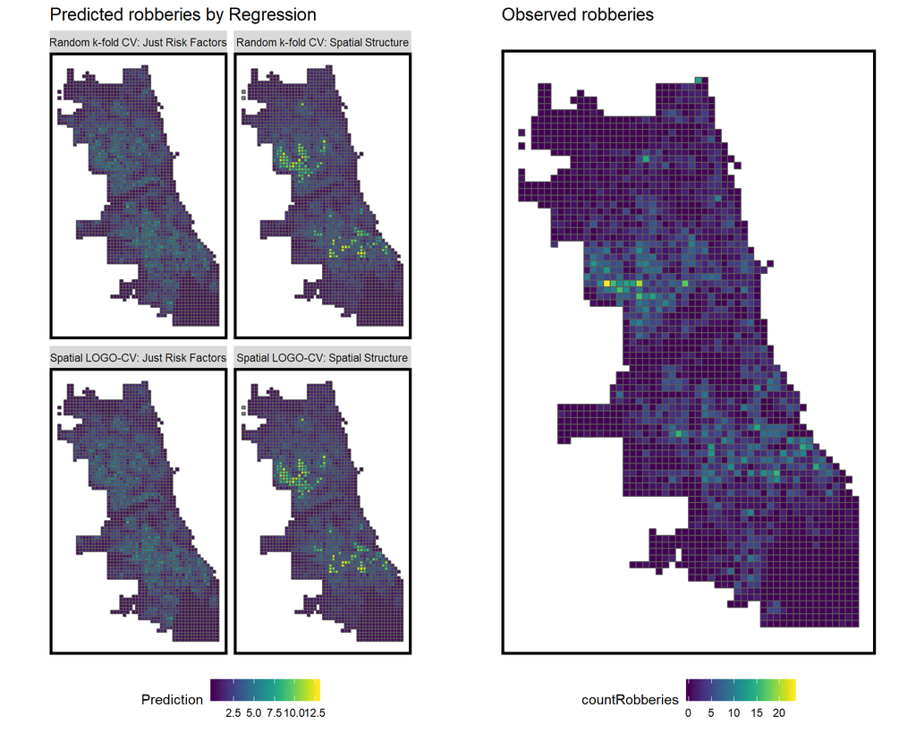

```r
# predictions for each Regression
grid.arrange(
  reg.summary %>%
    ggplot() +
    geom_sf(aes(fill = Prediction)) +
    facet_wrap(~Regression) +
    scale_fill_viridis() +
    labs(title = "Predicted robberies by Regression") +
    mapTheme() + theme(legend.position="bottom"),

  filter(reg.summary, Regression == "Random k-fold CV: Just Risk Factors") %>%
    ggplot() +
    geom_sf(aes(fill = countRobberies)) +
    scale_fill_viridis() +
    labs(title = "Observed robberies\n") +
    mapTheme() + theme(legend.position="bottom"), ncol = 2)
```

According to the maps, it’s clear that the models with spatial structure features are better in picking up on very localized hotspots.

### Deliverable 7. Small multiple map of model errors by random k-fold and spatial cross validation.

And then, for comparison, I mapped the prediction errors for two different specifications of both models.

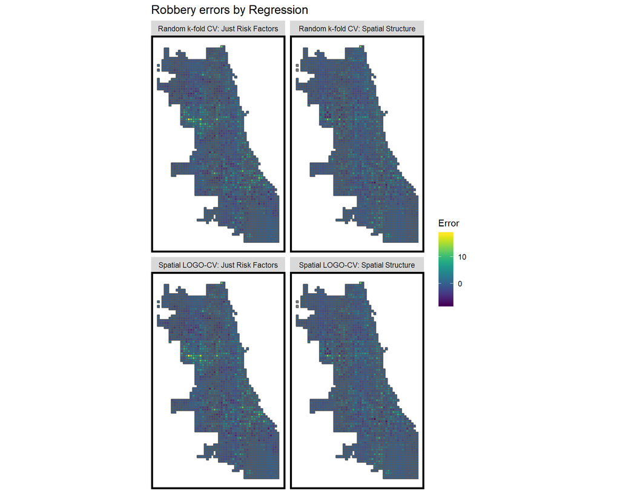

```r
# prediction errors maps
filter(reg.summary,  Regression == "Random k-fold CV: Just Risk Factors" |
         Regression == "Random k-fold CV: Spatial Structure" |
       Regression == "Spatial LOGO-CV: Just Risk Factors" |
         Regression == "Spatial LOGO-CV: Spatial Structure") %>%
  ggplot() +
  geom_sf(aes(fill = Error)) +
  facet_wrap(~Regression) +
  scale_fill_viridis() +
  labs(title = "Robbery errors by Regression") +
  mapTheme()
```

According to the maps of both approaches, the model without spatial structures seem to underpredict many hotspots and leave clustered errors at the hotspots. Besides, the distribution of the errors across different cross-validation types seems similar.

### Deliverable 8. Table of MAE and standard deviation MAE by regression.

Afterwards, I examined the MAE and standard deviation of MAE by each regression type and I found that the models err by about 1.2 robberies on average. Since the mean value of the count of robberies is about 1.9, the errors seem really large. Thus, in this perspective, the model seems very bad in prediction of robberies.

```r
st_set_geometry(reg.summary, NULL) %>%
  group_by(Regression) %>%
  summarize(MAE = round(mean(abs(Prediction - countRobberies), na.rm = T),2),
            SD_MAE = round(sd(abs(Prediction - countRobberies), na.rm = T),2)) %>%
  kable(caption = "MAE by regression") %>%
  kable_styling("striped", full_width = F) %>%
  row_spec(2, color = "white", background = "#004E87") %>%
  row_spec(4, color = "white", background = "#004E87")
```

MAE by regression

| Regression | MAE | SD_MAE |
| --- | --- | --- |
| Random k-fold CV: Just Risk Factors | 1.41 | 1.62 |
| Random k-fold CV: Spatial Structure | 1.19 | 1.28 |
| Spatial LOGO-CV: Just Risk Factors | 1.42 | 1.63 |
| Spatial LOGO-CV: Spatial Structure | 1.20 | 1.29 |

```r
mean(reg.summary$countRobberies)
```

```
## [1] 1.899419
```

Besides, since overpredicting would draw undue attetion to the minority neighborhoods, it might be particularly helpful to look at the raw errors rather than absolute errors. In addition, according to the table, it’s obvious that the regressions with the spatial structure features are more accurate and generalizable.

### Deliverable 9. Table of raw errors by race context for a random k-fold vs. spatial cross validation regression

Then, since the neighborhoods would have reporting or selection bias, to furtherly test the generalizability, I downloaded the ACS 2017 5-year race data to test the model in race context.Below is the table of the raw error by neighborhood race context.

```r
# Mean error by neighborhood racial context
final_reg <- reg.summary %>%
  mutate(uniqueID = rownames(.))

final_reg.tracts <-
  st_join(st_centroid(final_reg), tracts17) %>%
  st_set_geometry(NULL) %>%
  left_join(dplyr::select(final_reg, uniqueID)) %>%
  st_sf() %>%
  na.omit()

st_set_geometry(final_reg.tracts, NULL) %>%
  group_by(Regression, raceContext) %>%
  summarize(mean.Error = mean(Error, na.rm = T)) %>%
  spread(raceContext, mean.Error) %>%
  kable(caption = "Mean (Raw) Error by neighborhood racial context") %>%
  kable_styling("striped", full_width = F) %>%
  row_spec(2, color = "white", background = "#004E87") %>%
  row_spec(4, color = "white", background = "#004E87")
```

Mean (Raw) Error by neighborhood racial context

| Regression | Majority_Non_White | Majority_White |
| --- | --- | --- |
| Random k-fold CV: Just Risk Factors | 0.3235698 | -0.3462039 |
| Random k-fold CV: Spatial Structure | 0.1703148 | -0.1804835 |
| Spatial LOGO-CV: Just Risk Factors | 0.3348428 | -0.3566344 |
| Spatial LOGO-CV: Spatial Structure | 0.1854650 | -0.1884662 |

## 5. Prediction Model vs Kernal Density

In this section, I want to test if my model is better than traditional crime hotspots (kernal density). So, at first, I computed the needed components for kernel density of risk observations and predictions (from LOGO-CV).

```r
# observed #
# Compute kernel density
rob_ppp <- as.ppp(st_coordinates(rob), W = st_bbox(final_net))
rob_KD <- spatstat::density.ppp(rob_ppp, 1000)
# Convert kernel density to grid cells taking the mean
rob_KDE_sf <- as.data.frame(rob_KD) %>%
  st_as_sf(coords = c("x", "y"), crs = st_crs(final_net)) %>%
  aggregate(., final_net, mean) %>%
  #Mutate the Risk_Category field as defined below.
  mutate(label = "Kernel Density",
         Risk_Category = ntile(value, 100),
         Risk_Category = case_when(
           Risk_Category >= 90 ~ "90% to 100%",
           Risk_Category >= 70 & Risk_Category <= 89 ~ "70% to 89%",
           Risk_Category >= 50 & Risk_Category <= 69 ~ "50% to 69%",
           Risk_Category >= 30 & Risk_Category <= 49 ~ "30% to 49%",
           Risk_Category >= 1 & Risk_Category <= 29 ~ "1% to 29%")) %>%
  #Bind to a layer where test set crime counts are spatially joined to the fisnnet.
  bind_cols(
    aggregate(
      dplyr::select(rob) %>% mutate(robCount = 1), ., length) %>%
      mutate(robCount = replace_na(robCount, 0))) %>%
  #Select the fields we need
  dplyr::select(label, Risk_Category, robCount)

head(rob_KDE_sf)
```

```
## Simple feature collection with 6 features and 3 fields
## geometry type:  POLYGON
## dimension:      XY
## bbox:           xmin: 359664.1 ymin: 552875.4 xmax: 362664.1 ymax: 553375.4
## epsg (SRID):    NA
## proj4string:    +proj=tmerc +lat_0=36.66666666666666 +lon_0=-88.33333333333333 +k=0.9999749999999999 +x_0=300000 +y_0=0 +ellps=GRS80 +units=m +no_defs
##            label Risk_Category robCount                       geometry
## 1 Kernel Density    30% to 49%        1 POLYGON ((359664.1 552875.4...
## 2 Kernel Density    30% to 49%        0 POLYGON ((360164.1 552875.4...
## 3 Kernel Density    30% to 49%        0 POLYGON ((360664.1 552875.4...
## 4 Kernel Density     1% to 29%        0 POLYGON ((361164.1 552875.4...
## 5 Kernel Density     1% to 29%        0 POLYGON ((361664.1 552875.4...
## 6 Kernel Density     1% to 29%        0 POLYGON ((362164.1 552875.4...
```

```r
# predictions (LOGO-CV) #
rob_risk_sf <-
  filter(final_reg, Regression == "Spatial LOGO-CV: Spatial Structure") %>%
  mutate(label = "Risk Predictions",
         Risk_Category = ntile(Prediction, 100),
         Risk_Category = case_when(
           Risk_Category >= 90 ~ "90% to 100%",
           Risk_Category >= 70 & Risk_Category <= 89 ~ "70% to 89%",
           Risk_Category >= 50 & Risk_Category <= 69 ~ "50% to 69%",
           Risk_Category >= 30 & Risk_Category <= 49 ~ "30% to 49%",
           Risk_Category >= 1 & Risk_Category <= 29 ~ "1% to 29%")) %>%
  bind_cols(
    aggregate(
      dplyr::select(rob) %>% mutate(robCount = 1), ., length) %>%
      mutate(robCount = replace_na(robCount, 0))) %>%
  dplyr::select(label,Risk_Category, robCount)
```

### Deliverable 10. Map comparing kernel density to risk predictions.

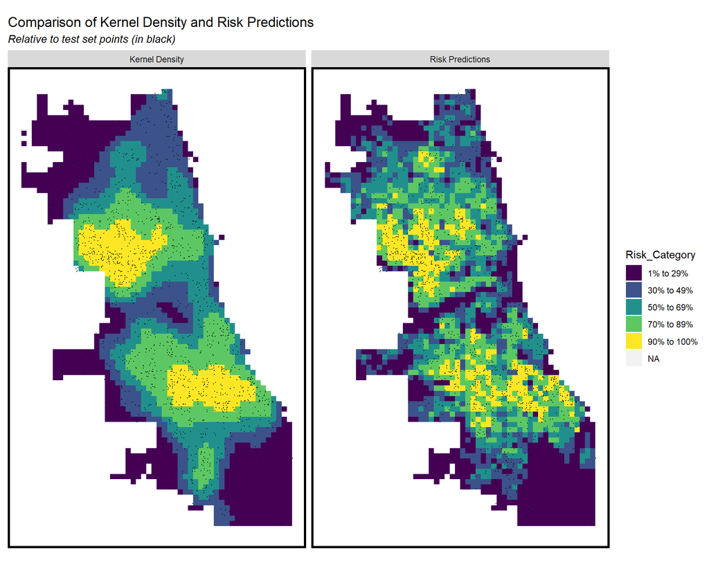

```r
rbind(rob_KDE_sf, rob_risk_sf) %>%
  gather(Variable, Value, -label, -Risk_Category, -geometry) %>%
  ggplot() +
  geom_sf(aes(fill = Risk_Category), colour = NA) +
  geom_sf(data = sample_n(rob, 1500), size = .1, colour = "black") +
  facet_wrap(~label, ) +
  scale_fill_viridis(discrete = TRUE) +
  labs(title="Comparison of Kernel Density and Risk Predictions",
       subtitle="Relative to test set points (in black)") +
  mapTheme()
```

### Deliverable 11. Rate of robbery points by risk category and model type (Bar Plot).

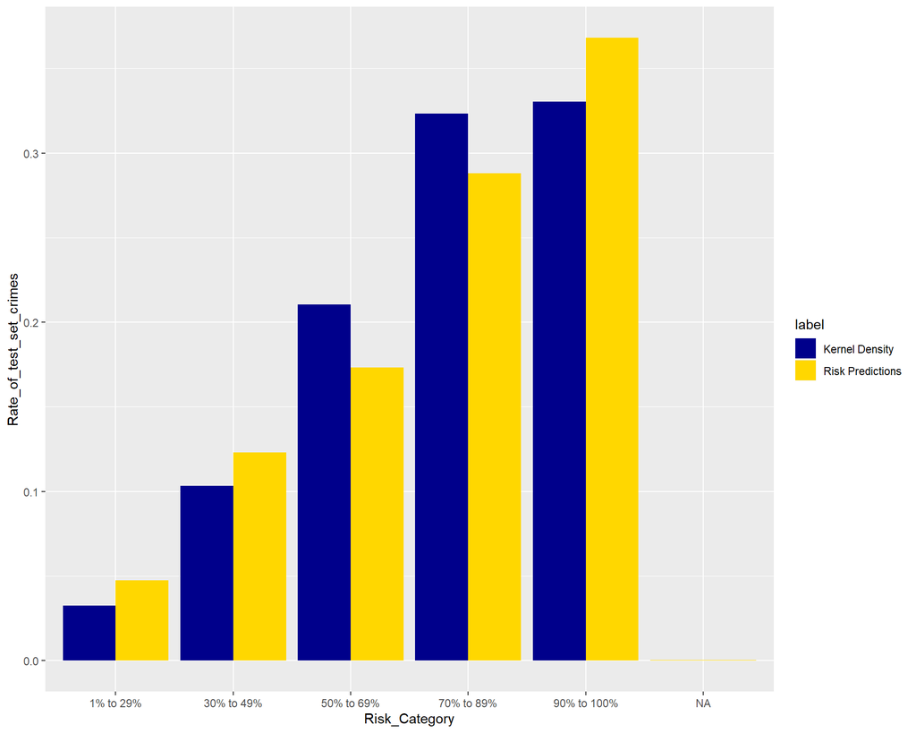

```r
# rate of robbery points by risk category and model type
rbind(rob_KDE_sf, rob_risk_sf) %>%
  st_set_geometry(NULL) %>%
  gather(Variable, Value, -label, -Risk_Category) %>%
  group_by(label, Risk_Category) %>%
  summarize(countRobberies = sum(Value)) %>%
  ungroup() %>%
  group_by(label) %>%
  mutate(Rate_of_test_set_crimes = countRobberies / sum(countRobberies)) %>%
  ggplot(aes(Risk_Category,Rate_of_test_set_crimes)) +
  geom_bar(aes(fill=label), position="dodge", stat="identity") +
  scale_fill_viridis(discrete = TRUE) +
  scale_fill_manual("label", values = c("Kernel Density" = "Dark Blue", "Risk Predictions" = "Gold"))
```